# Sample Report - Data Science Capstone

Author

Dinesh

Published

February 5, 2024

## Method

The common non-parametric regression model is $Y_i = m(X_i) + \varepsilon_i$, where $Y_i$ can be defined as the sum of the regression function value $m(x)$ for $X_i$. Here $m(x)$ is unknown and $\varepsilon_i$ some errors. With the help of this definition, we can create the estimation for local averaging i.e. $m(x)$ can be estimated with the product of $Y_i$ average and $X_i$ is near to $x$. In other words, this means that we are discovering the line through the data points with the help of surrounding data points. The estimation formula is printed below (R Core Team 2019):

$$M_n(x) = \sum_{i=1}^{n} W_n (X_i) Y_i \tag{1}$$
$W_n(x)$ is the sum of weights that belongs to all real numbers. Weights are positive numbers and small if $X_i$ is far from $x$.

Another equation:

$$y_i = \beta_0 + \beta_1 X_1 +\varepsilon_i$$

## Analysis and Results

### Data and Visualization

```r
# loading packages
library(tidyverse)
library(knitr)
library(ggthemes)
library(ggrepel)
library(dslabs)
```

```r
# Load Data
kable(head(murders))
```

| state | abb | region | population | total |
| --- | --- | --- | --- | --- |
| Alabama | AL | South | 4779736 | 135 |
| Alaska | AK | West | 710231 | 19 |
| Arizona | AZ | West | 6392017 | 232 |
| Arkansas | AR | South | 2915918 | 93 |
| California | CA | West | 37253956 | 1257 |
| Colorado | CO | West | 5029196 | 65 |

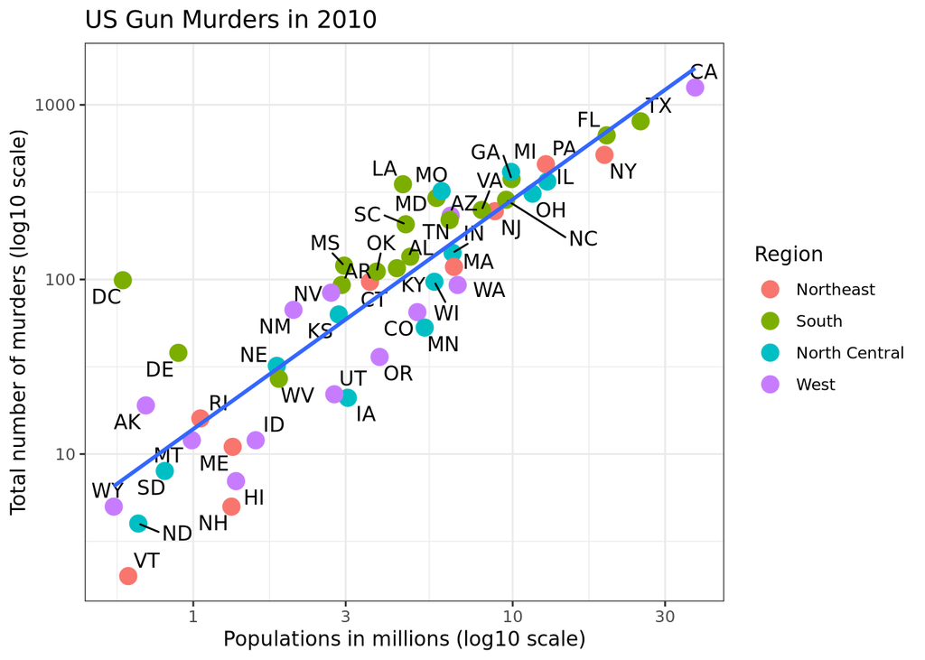

```r
ggplot1 = murders %>% ggplot(mapping = aes(x=population/10^6, y=total))

  ggplot1 + geom_point(aes(col=region), size = 4) +
  geom_text_repel(aes(label=abb)) +
  scale_x_log10() +
  scale_y_log10() +
  geom_smooth(formula = "y~x", method=lm,se = F)+
  xlab("Populations in millions (log10 scale)") +
  ylab("Total number of murders (log10 scale)") +
  ggtitle("US Gun Murders in 2010") +
  scale_color_discrete(name = "Region")+
      theme_bw()
```

### Conclusion

Article 1:

This study emphasizes that in an era of increased data output, there is a growing demand for strong, rapid, and accurate algorithms for data analysis. Benefits of Support Vector Machines (SVM) as a potent machine learning technique for a range of statistical learning issues, including bioinformatics, are highlighted. In particular, SVMs are well-known for their use of kernel functions and generalization theory, which allow for the creation of non-linear decision surfaces for tasks involving regression and classification. The study presents a summary of Support Vector Machines (SVM), examines both linear and non-linear classification, and highlights the significance of kernel selection. It also covers a variety of data mining classification approaches before recognizing some of SVM’s drawbacks, including the difficulty of selecting the best kernel for a given situation and issues with performance and size.

Article 2:

The Development and Application of Support Vector Machine

Jun, Z. (2021). The development and application of support vector machine. In *Journal of Physics: Conference Series* (Vol. 1748, No. 5, p. 052006). IOP Publishing.

The article gives an introduction to the Support Vector Machine (SVM) method, highlighting its benefits, fundamental ideas, and uses in face identification, protein prediction, and contemporary machining. It explores the theoretical underpinnings of support vector machines (SVM), going over ideas like kernel functions and hard and soft margins. The application sections show off effective SVM implementations across a range of disciplines, demonstrating its effectiveness in face detection, protein type prediction, and bearing defect diagnostics. The paper highlights the adaptability and generalization power of SVM while also pointing out some of its possible drawbacks, especially with regard to training efficiency for large-scale datasets. The study’s finding implies that future work might concentrate on enhancing SVM algorithms and increasing the range of real-world uses for them.

Article 3:

Overview of Support Vector Machine in Modeling Machining Performances

Deris, A. M., Zain, A. M., & Sallehuddin, R. (2011). Overview of support vector machine in modeling machining performances. *Procedia Engineering*, *24*, 308-312.

The use of Support Vector Machines (SVM) to model machining performances is covered in this study, focusing on both traditional and contemporary machining procedures. Researchers from Universiti Teknologi Malaysia draw attention to the difficulties in simulating and improving machining operations as well as the growing use of computational methods like SVM. Surface roughness, tool wear, tool breakage, and defect diagnostics are just a few of the machining factors that are modeled by the Support Vector Machine (SVM), a potent mathematical tool for data classification, regression, and function estimation. The review highlights how well SVM handles the intricacy of machining processes and how widely it is used to produce high-quality items with economical predictions. The study emphasizes SVM’s function as a flexible and trustworthy modeling approach in the developing field of machining.

Article 4:

Tutorial on Support Vector Machine (SVM)

Jakkula, V. (2006). Tutorial on support vector machine (svm). *School of EECS, Washington State University*, *37*(2.5), 3.

The author gives an introduction to Support Vector Machines (SVM) like its mathematical foundation and practical uses. SVMs are presented as a collection of supervised learning techniques for regression and classification. The course explores the mathematical support of support vector machines (SVM), giving ideas like structural risk minimization, maximum margin classifier, and SVM formulation for linear scenarios. It emphasizes how important SVM is for tasks involving pattern recognition and how it may be extended to solve regression issues. Important SVM topics including statistical learning theory, generalization, and the kernel trick are also covered in the session. The author talks about how kernels help SVM handle non-linear boundaries by converting input data into a high-dimensional feature space. Numerous kernel functions are investigated, such as the polynomial, multi-layer perceptron, exponential, and Gaussian radial basis functions. The last section covers the uses of SVM in regression and classification, highlighting how well it works in pattern classification scenarios and how well it can handle high-dimensional data. SVM’s advantages and disadvantages are discussed, with an emphasis on its scalability, training simplicity, and the significance of choosing the right kernel function.

## References

Bro, Rasmus, and Age K Smilde. 2014. “Principal Component Analysis.” *Analytical Methods* 6 (9): 2812–31.

Efromovich, S. 2008. *Nonparametric Curve Estimation: Methods, Theory, and Applications*. Springer Series in Statistics. Springer New York. https://books.google.com/books?id=mdoLBwAAQBAJ.

R Core Team. 2019. *R: A Language and Environment for Statistical Computing*. Vienna, Austria: R Foundation for Statistical Computing. https://www.R-project.org.

Wang, Ming. 2014. “Generalized Estimating Equations in Longitudinal Data Analysis: A Review and Recent Developments.” *Advances in Statistics* 2014.